Skip to content

BZ Homepage

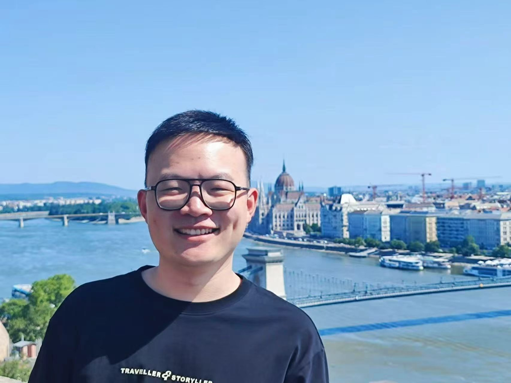

# Bolin Zhang 张博麟

Lecturer

[School of Artificial Intelligence](https://eecs.nbu.edu.cn/)  
[Ningbo University](https://www.nbu.edu.cn/)

818 Fenghua Road, Jiangbei District  
Ningbo, Zhejiang, China

zhangbolin@nbu.edu.cn [ORCID ↗](https://orcid.org/0009-0006-1728-9682) [Google Scholar ↗](https://scholar.google.com/citations?user=bL2bB0QAAAAJ&hl=zh-CN)

## About Me

I am a lecturer at the [School of Artificial Intelligence](https://eecs.nbu.edu.cn/), [Ningbo University](https://www.nbu.edu.cn/). I study **cross-modal retrieval**. One question at the center of my work is how to find the few seconds in a long video that match a sentence.

My research interests include video moment localization and hashing for large-scale retrieval. I also work on matching food photographs with recipes, where a dish’s name, ingredients, and cooking instructions each offer different clues.

I received my Ph.D. from Hunan University in 2024, advised by [Bin Jiang](https://csee.hnu.edu.cn/people/jiangbin) and [Chao Yang](https://csee.hnu.edu.cn/people/yangchao). With support from the China Scholarship Council, I visited the [Contents Science Lab](https://www.cs.is.i.nagoya-u.ac.jp/) at Nagoya University and worked with [Ichiro Ide](https://www.cs.is.i.nagoya-u.ac.jp/users/ide/) and [Takahiro Komamizu](https://taka-coma.pro/).

Outside the lab, I enjoy running and traveling in search of regional food. Someday I’d like to write a food blog and finish a marathon.

## Our Lab

[figure not shown]

## News

- **Oct 2026** · DOI registered · [*IEEE Transactions on Multimedia*](https://doi.org/10.1109/tmm.2026.3742151). We match food photos to recipes using a shared text encoder that learns relationships both within a recipe and between recipes and images.
- **Oct 2026** · [*IEEE Transactions on Big Data*](https://doi.org/10.1109/tbdata.2026.3702369). DS-Model uses one network to guide a second network as it learns to recognize distracted driving.
- **Sep 2026** · DOI registered · [*Neurocomputing*](https://doi.org/10.1016/j.neucom.2026.135255). Our model locates an object from an ambiguous description by resolving what the words refer to and selecting the relevant scene information.
- **Apr 2026** · [*Vehicles*](https://doi.org/10.3390/vehicles8040083). ICK-PANet combines attention with pyramid convolutions to recognize distracted driving from visual cues at different scales.

**Earlier news**

- **2026** · [*Vehicles*](https://doi.org/10.3390/vehicles8040074). Dual-Flow Driver Distraction Driving Detection Model Based on Sobel Edge Detection
- **Nov 2025** · DOI registered · [*IEEE Transactions on Geoscience and Remote Sensing*](https://doi.org/10.1109/tgrs.2025.3636865). SpikeHCD detects changes between hyperspectral images of the same scene.
- **Oct 2025** · [*ACM Trans. Multimedia Comput. Commun. Appl.*](https://doi.org/10.1145/3716388). Our retrieval model learns from CLIP at the frame, clip, and video levels to find videos in which only part of the footage matches the query.
- **2025** · [*International Journal of Machine Learning and Cybernetics*](https://doi.org/10.1007/s13042-024-02520-w). Our model learns to locate video moments from sentence descriptions without needing start and end times during training.
- **Dec 2024** · [*Knowledge-Based Systems*](https://doi.org/10.1016/j.knosys.2024.112641). One text encoder represents a recipe at multiple levels and matches its title, ingredients, and instructions to the food image.
- **July 2024** · I joined Ningbo University after completing my Ph.D. at Hunan University.
- **2024** · [*Multimedia Tools and Applications*](https://doi.org/10.1007/s11042-023-16377-8). DE-GAN: Text-to-image synthesis with dual and efficient fusion model
- **2023** · [*International Journal of Machine Learning and Cybernetics*](https://doi.org/10.1007/s13042-023-01844-3). OSAGGAN: one-shot unsupervised image-to-image translation using attention-guided generative adversarial networks
- **2022** · [*Big Data Mining and Analytics*](https://doi.org/10.26599/bdma.2021.9020020). MAGAN: Unsupervised low-light image enhancement guided by mixed-attention
- **2021** · [*Applied Intelligence*](https://doi.org/10.1007/s10489-020-02180-7). We use a capsule network to learn compact codes for image retrieval while retaining information about how image features fit together.
- **2021** · [*Applied Intelligence*](https://doi.org/10.1007/s10489-020-01797-y). We train an autoencoder to cluster unlabeled data and learn compact hash codes for searching large collections.

## Publications Bolin Zhang: * First author · <sup>✉</sup> Corresponding author

1. Neurocomputing · 2027

### [Improving scene knowledge visual grounding via coreference awareness and adaptive knowledge reallocation](https://doi.org/10.1016/j.neucom.2026.135255)

   Chenglong Lei, Chao Yang, **Bolin Zhang**, Hu Guo, Bin Jiang

   Neurocomputing, 2027.

   [Paper](https://doi.org/10.1016/j.neucom.2026.135255)

   **BibTeX**

   ```
   @article{journal-fa1d04968b3fa6cb,
     title = {Improving scene knowledge visual grounding via coreference awareness and adaptive knowledge reallocation},
     author = {Lei, Chenglong and Yang, Chao and Zhang, Bolin and Guo, Hu and Jiang, Bin},
     journal = {Neurocomputing},
     year = {2027},
     volume = {708},
     pages = {135255},
     doi = {10.1016/j.neucom.2026.135255},
     url = {https://doi.org/10.1016/j.neucom.2026.135255},
   }
   ```

2. IEEE Trans. Big Data · 2026

### [DS-Model: Dual-Stream Driver Distraction Detection Model Based on Guiding Learning](https://doi.org/10.1109/tbdata.2026.3702369)

   Binbin Qin, **Bolin Zhang**, Jiangbo Qian

   IEEE Transactions on Big Data, 2026.

   [Paper](https://doi.org/10.1109/tbdata.2026.3702369)

   **BibTeX**

   ```
   @article{journal-ef004e7b04d3cb71,
     title = {DS-Model: Dual-Stream Driver Distraction Detection Model Based on Guiding Learning},
     author = {Qin, Binbin and Zhang, Bolin and Qian, Jiangbo},
     journal = {IEEE Transactions on Big Data},
     year = {2026},
     volume = {12},
     number = {5},
     pages = {1785-1801},
     doi = {10.1109/tbdata.2026.3702369},
     url = {https://doi.org/10.1109/tbdata.2026.3702369},
   }
   ```

3. Vehicles · 2026

### [ICK-PANet: A Multiscale Driver Distraction Detection Network Based on Attention and Pyramid Convolution](https://doi.org/10.3390/vehicles8040083)

   Binbin Qin, **Bolin Zhang**, Jiangbo Qian

   Vehicles, 2026.

   [Paper](https://doi.org/10.3390/vehicles8040083)

   **BibTeX**

   ```
   @article{journal-180eea614da15cbd,
     title = {ICK-PANet: A Multiscale Driver Distraction Detection Network Based on Attention and Pyramid Convolution},
     author = {Qin, Binbin and Zhang, Bolin and Qian, Jiangbo},
     journal = {Vehicles},
     year = {2026},
     volume = {8},
     number = {4},
     pages = {83},
     doi = {10.3390/vehicles8040083},
     url = {https://doi.org/10.3390/vehicles8040083},
   }
   ```

4. IEEE Trans. Multimedia · 2026

### [Unified Text Encoder With Intra- and Inter-Modal Contrastive Learning for Cross-Modal Recipe Retrieval](https://doi.org/10.1109/tmm.2026.3742151)

   **Bolin Zhang***, Jianhao Li, Chao Yang, Bin Jiang, Takahiro Komamizu, Ichiro Ide, Jiangbo Qian

   IEEE Transactions on Multimedia, 2026.

   [Paper](https://doi.org/10.1109/tmm.2026.3742151)

   **BibTeX**

   ```
   @article{journal-3aca7ffd8e2e3db6,
     title = {Unified Text Encoder With Intra- and Inter-Modal Contrastive Learning for Cross-Modal Recipe Retrieval},
     author = {Zhang, Bolin and Li, Jianhao and Yang, Chao and Jiang, Bin and Komamizu, Takahiro and Ide, Ichiro and Qian, Jiangbo},
     journal = {IEEE Transactions on Multimedia},
     year = {2026},
     volume = {28},
     pages = {17445-17458},
     doi = {10.1109/tmm.2026.3742151},
     url = {https://doi.org/10.1109/tmm.2026.3742151},
   }
   ```

5. Preprint · 2026

### [Static and Dynamic Graph Alignment Network for Temporal Video Grounding](https://doi.org/10.48550/arXiv.2605.00684)

   Zhanjie Hu, **Bolin Zhang**<sup>✉</sup>, Jianhua Wang, Jianbo Zheng, Chenchen Yan, Takahiro Komamizu, Ichiro Ide, Jiangbo Qian

   arXiv preprint 2605.00684, 2026.

   [Paper](https://doi.org/10.48550/arXiv.2605.00684)

   **BibTeX**

   ```
   @misc{arXiv260500684,
     title = {Static and Dynamic Graph Alignment Network for Temporal Video Grounding},
     author = {Hu, Zhanjie and Zhang, Bolin and Wang, Jianhua and Zheng, Jianbo and Yan, Chenchen and Komamizu, Takahiro and Ide, Ichiro and Qian, Jiangbo},
     year = {2026},
     howpublished = {arXiv preprint},
     booktitle = {arXiv preprint 2605.00684},
     doi = {10.48550/arXiv.2605.00684},
     url = {https://arxiv.org/abs/2605.00684}
   }
   ```

6. Vehicles · 2026

### [Dual-Flow Driver Distraction Driving Detection Model Based on Sobel Edge Detection](https://doi.org/10.3390/vehicles8040074)

   Binbin Qin, **Bolin Zhang**<sup>✉</sup>

   Vehicles, 2026.

   [Paper](https://doi.org/10.3390/vehicles8040074)

   **BibTeX**

   ```
   @article{QinDualFlow2026,
     title = {Dual-Flow Driver Distraction Driving Detection Model Based on Sobel Edge Detection},
     author = {Qin, Binbin and Zhang, Bolin},
     journal = {Vehicles},
     year = {2026},
     volume = {8},
     number = {4},
     eid = {74},
     doi = {10.3390/vehicles8040074},
     url = {https://doi.org/10.3390/vehicles8040074}
   }
   ```

7. Preprint · 2025

### [Temporal-Aware Spiking Transformer Hashing Based on 3D-DWT](https://doi.org/10.48550/arXiv.2501.06786)

   Zihao Mei, Jianhao Li, **Bolin Zhang**, Chong Wang, Lijun Guo, Guoqi Li, Jiangbo Qian

   arXiv preprint 2501.06786, 2025.

   [Paper](https://doi.org/10.48550/arXiv.2501.06786)

   **BibTeX**

   ```
   @misc{arXiv250106786,
     title = {Temporal-Aware Spiking Transformer Hashing Based on 3D-DWT},
     author = {Mei, Zihao and Li, Jianhao and Zhang, Bolin and Wang, Chong and Guo, Lijun and Li, Guoqi and Qian, Jiangbo},
     year = {2025},
     howpublished = {arXiv preprint},
     booktitle = {arXiv preprint 2501.06786},
     doi = {10.48550/arXiv.2501.06786},
     url = {https://arxiv.org/abs/2501.06786}
   }
   ```

8. TGRS · 2025

### [SpikeHCD: Spiking Transformer With Parallel Neurons and Memory-Enhanced Attention for Hyperspectral Change Detection](https://doi.org/10.1109/TGRS.2025.3636865)

   Zihao Mei, Jianhao Li, **Bolin Zhang**, Chong Wang, Lijun Guo, Jiangbo Qian

   IEEE Transactions on Geoscience and Remote Sensing, 2025.

   [Paper](https://doi.org/10.1109/TGRS.2025.3636865) [PDF](https://ieeexplore.ieee.org/stamp/stamp.jsp?tp=&arnumber=11268463)

   **Abstract**

   The hyperspectral change detection (CD) is a critical technology in remote sensing, widely applied in urban planning, environmental monitoring, and disaster detection. However, the hyperspectral data exhibits higher spectral dimensionality compared to conventional RGB data, making existing methods struggle to balance high accuracy and low energy consumption. As the third generation of neural networks, spiking neural networks (SNNs) demonstrate the advantage of low energy efficiency, but the iterative computational process in spiking neurons significantly increases training and inference burdens when applied to hyperspectral CD. To address these challenges, we propose a novel spiking Transformer with parallel neurons and memory-enhanced attention for hyperspectral CD named SpikeHCD, the first SNNs specifically designed for hyperspectral CD. SpikeHCD not only maintains a low-energy advantage but also employs a probability-driven parallel spiking neurons (PPSN) to improve the computational efficiency, enabling more effective application in remote sensing tasks. We further design a memory-enhanced spiking attention (MSA) module to enhance temporal modeling capability, and thoroughly extract spatial–spectral features. In addition, a spiking difference module (SDM) is introduced to capture change features across different timesteps. Experimental results demonstrate that SpikeHCD can achieve several state-of-the-art (SOTA) results on multiple hyperspectral datasets, with faster detection, lower energy consumption, and fewer number of parameters. The codes are available at: https://github.com/mzhcode/HCD_snn

   **BibTeX**

   ```
   @article{SpikeHCD,
     author = {Mei, Zihao and Li, Jianhao and Zhang, Bolin and Wang, Chong and Guo, Lijun and Qian, Jiangbo},
     journal = {IEEE Transactions on Geoscience and Remote Sensing},
     title = {SpikeHCD: Spiking Transformer With Parallel Neurons and Memory-Enhanced Attention for Hyperspectral Change Detection},
     year = {2025},
     volume = {63},
     number = {},
     pages = {1--12},
     keywords = {Neurons;Hyperspectral imaging;Feature extraction;Transformers;Mathematical models;Biological system modeling;Membrane potentials;Computational efficiency;Attention mechanisms;Training;Attention mechanism;change detection (CD);hyperspectral image (HSI);spiking neural networks (SNNs)},
     url = {https://ieeexplore.ieee.org/abstract/document/11268463},
     doi = {10.1109/TGRS.2025.3636865},
   }
   ```

9. TOMM · 2025

### [Multi-Grained Alignment with Knowledge Distillation for Partially Relevant Video Retrieval](https://doi.org/10.1145/3716388)

   Qun Zhang, Chao Yang, Bin Jiang, **Bolin Zhang**

   ACM Trans. Multimedia Comput. Commun. Appl., 2025.

   [Paper](https://doi.org/10.1145/3716388) [PDF](https://dl.acm.org/doi/epdf/10.1145/3716388)

   **Abstract**

   Partially Relevant Video Retrieval (PRVR) aims to accurately retrieve the most relevant video in response to a query from untrimmed videos. The analysis of video content can be done at three different granularities: frame-level, clip-level, and video-level. Previous methods have focused on one or two of these levels for alignment, limiting the exploration of the video semantics. Moreover, some methods use video-level alignment and apply a self-attention mechanism to generate video-level features, but this may not be ideal as the entire video may not be relevant to the query. We propose a Multi-Grained Alignment framework with Knowledge Distillation (MGAKD), which purifies the cross-modal alignment knowledge from the Contrastive Language-Image Pre-training (CLIP) model and achieves multi-grained alignment. It extracts cross-modal alignment knowledge from CLIP and imparts this knowledge to the designed student model. For the student model, two branches are designed: an inheritance branch and an exploration branch. The inheritance branch absorbs the knowledge of cross-modal alignment from the CLIP. The exploration branch explores visual features at three granularities: frame-level, clip-level, and video-level. Specifically, we directly align the extracted frame features of the video with the query features to achieve frame-level alignment. In clip-level alignment, the use of Gaussian masks allows for the representation of the beginning, climax, and end of an event. By employing Gaussian masks, we are able to implicitly model clip-level features, resulting in clip features that contain a richer set of contextual information. To further enhance video-level feature exploration, we apply clip-guided attention to generate diverse video-level features based on different queries. This strategy effectively prevents irrelevant video moments from affecting the alignment of videos and queries. We conduct extensive experiments on two publicly available datasets, and the experimental results have surpassed those of the state-of-the-art method, showcasing the superior performance of the proposed method.

   **BibTeX**

   ```
   @article{MGAKD,
     author = {Zhang, Qun and Yang, Chao and Jiang, Bin and Zhang, Bolin},
     title = {Multi-Grained Alignment with Knowledge Distillation for Partially Relevant Video Retrieval},
     year = {2025},
     issue_date = {October 2025},
     publisher = {Association for Computing Machinery},
     address = {New York, NY, USA},
     volume = {21},
     number = {10},
     issn = {1551-6857},
     url = {https://doi.org/10.1145/3716388},
     doi = {10.1145/3716388},
     journal = {ACM Trans. Multimedia Comput. Commun. Appl.},
     month = oct,
     articleno = {285},
     numpages = {22},
     keywords = {Text-Video Retrieval, Partially Relevant Video Retrieval, Multi-modal Alignment},
   }
   ```

10. IJMLC · 2025

### [Multi-proposal collaboration and multi-task training for weakly-supervised video moment retrieval](https://doi.org/10.1007/s13042-024-02520-w)

    **Bolin Zhang***, Chao Yang, Bin Jiang, Takahiro Komamizu, Ichiro Ide

    International Journal of Machine Learning and Cybernetics, 2025.

    [Paper](https://doi.org/10.1007/s13042-024-02520-w) [PDF](https://link.springer.com/content/pdf/10.1007/s13042-024-02520-w.pdf)

    **Abstract**

    This study focuses on weakly-supervised Video Moment Retrieval (VMR), aiming to identify a moment semantically similar to the given query within an untrimmed video using only video-level correspondences, without relying on temporal annotations during training. Previous methods either aggregate predictions for all instances in the video, or indirectly address the task by proposing reconstructions for the query. However, these methods often produce low-quality temporal proposals, struggle with distinguishing misaligned moments in the same video, or lack stability due to a reliance on a single auxiliary task. To address these limitations, we present a novel weakly-supervised method called Multi-proposal Collaboration and Multi-task Training (MCMT). Initially, we generate multiple proposals and derive corresponding learnable Gaussian masks from them. These masks are then combined to create a high-quality positive sample mask, highlighting video clips most relevant to the query. Concurrently, we classify other clips in the same video as the easy negative sample and the entire video as the hard negative sample. During training, we introduce forward and inverse masked query reconstruction tasks to impose more substantial constraints on the network, promoting more robust and stable retrieval performance. Extensive experiments on two standard benchmarks affirm the effectiveness of the proposed method in VMR.

    **BibTeX**

    ```
    @article{MCMT,
      title = {Multi-proposal collaboration and multi-task training for weakly-supervised video moment retrieval},
      author = {Zhang, Bolin and Yang, Chao and Jiang, Bin and Komamizu, Takahiro and Ide, Ichiro},
      journal = {International Journal of Machine Learning and Cybernetics},
      volume = {16},
      number = {7},
      pages = {4509--4524},
      year = {2025},
      publisher = {Springer},
      issn = {1868--808X},
      url = {https://doi.org/10.1007/s13042-024-02520-w},
      doi = {10.1007/s13042-024-02520-w}
    }
    ```

11. Preprint · 2025

### [Multi-Focused Video Group Activities Hashing](https://doi.org/10.48550/arXiv.2509.00490)

    Zhongmiao Qi, Yan Jiang, **Bolin Zhang**, Chong Wang, Lijun Guo, Pengjiang Qian, Jiangbo Qian

    arXiv preprint 2509.00490, 2025.

    [Paper](https://doi.org/10.48550/arXiv.2509.00490)

    **BibTeX**

    ```
    @misc{arXiv250900490,
      title = {Multi-Focused Video Group Activities Hashing},
      author = {Qi, Zhongmiao and Jiang, Yan and Zhang, Bolin and Wang, Chong and Guo, Lijun and Qian, Pengjiang and Qian, Jiangbo},
      year = {2025},
      howpublished = {arXiv preprint},
      booktitle = {arXiv preprint 2509.00490},
      doi = {10.48550/arXiv.2509.00490},
      url = {https://arxiv.org/abs/2509.00490}
    }
    ```

12. KBS · 2024

### [Cross-modal recipe retrieval based on unified text encoder with fine-grained contrastive learning](https://doi.org/10.1016/j.knosys.2024.112641)

    **Bolin Zhang***, Haruya Kyutoku, Keisuke Doman, Takahiro Komamizu, Ichiro Ide, Jiangbo Qian

    Knowledge-Based Systems, 2024.

    One text encoder represents a recipe at multiple levels and matches its title, ingredients, and instructions to the food image.

    [Paper](https://doi.org/10.1016/j.knosys.2024.112641) [Code](https://github.com/onlyouzbl/UTE-FCL) [PDF](https://www.sciencedirect.com/science/article/pii/S0950705124012759/pdfft?md5=cce5ae60919f84b076564f16e6a2857d&pid=1-s2.0-S0950705124012759-main.pdf)

    **Abstract**

    Cross-modal recipe retrieval is vital for transforming visual food cues into actionable cooking guidance, making culinary creativity more accessible. Existing methods separately encode the recipe Title, Ingredient, and Instruction using different text encoders, then aggregate them to obtain recipe feature, and finally match it with encoded image feature in a joint embedding space. These methods perform well but require significant computational cost. In addition, they only consider matching the entire recipe and the image but ignore the fine-grained correspondence between recipe components and the image, resulting in insufficient cross-modal interaction. To this end, we propose Unified Text Encoder with Fine-grained Contrastive Learning (UTE-FCL) to achieve a simple but efficient model. Specifically, in each recipe, UTE-FCL first concatenates each of the Ingredient and Instruction texts composed of multiple sentences as a single text. Then, it connects these two concatenated texts with the original single-phrase Title to obtain the concatenated recipe. Finally, it encodes these three concatenated texts and the original Title by a Transformer-based Unified Text Encoder (UTE). This proposed structure greatly reduces the memory usage and improves the feature encoding efficiency. Further, we propose fine-grained contrastive learning objectives to capture the correspondence between recipe components and the image at Title, Ingredient, and Instruction levels by measuring the mutual information. Extensive experiments demonstrate the effectiveness of UTE-FCL compared to existing methods.

    **BibTeX**

    ```
    @article{UTE-FCL,
      title = {Cross-modal recipe retrieval based on unified text encoder with fine-grained contrastive learning},
      journal = {Knowledge-Based Systems},
      volume = {305},
      pages = {112641},
      year = {2024},
      issn = {0950--7051},
      doi = {10.1016/j.knosys.2024.112641},
      url = {https://www.sciencedirect.com/science/article/pii/S0950705124012759},
      author = {Zhang, Bolin and Kyutoku, Haruya and Doman, Keisuke and Komamizu, Takahiro and Ide, Ichiro and Qian, Jiangbo},
      keywords = {Cross-modal recipe retrieval, Unified text encoder, Contrastive learning},
    }
    ```

13. ChineseCSCW · 2024

### [CMGN: Cross-Modal Grounding Network for Temporal Sentence Retrieval in Video](https://doi.org/10.1007/978-981-99-9640-7_19)

    Qun Zhang, Bin Jiang, **Bolin Zhang**, Chao Yang

    Computer Supported Cooperative Work and Social Computing, 2024.

    [Paper](https://doi.org/10.1007/978-981-99-9640-7_19)

    **BibTeX**

    ```
    @inproceedings{Zhang2024Conference,
      title = {CMGN: Cross-Modal Grounding Network for Temporal Sentence Retrieval in Video},
      author = {Zhang, Qun and Jiang, Bin and Zhang, Bolin and Yang, Chao},
      year = {2024},
      booktitle = {Computer Supported Cooperative Work and Social Computing},
      pages = {265-275},
      doi = {10.1007/978-981-99-9640-7_19},
      url = {https://doi.org/10.1007/978-981-99-9640-7_19}
    }
    ```

14. MTAP · 2024

### [DE-GAN: Text-to-image synthesis with dual and efficient fusion model](https://doi.org/10.1007/s11042-023-16377-8)

    Bin Jiang, Weiyuan Zeng, Chao Yang, Renjun Wang, **Bolin Zhang**

    Multimedia Tools and Applications, 2024.

    [Paper](https://doi.org/10.1007/s11042-023-16377-8)

    **BibTeX**

    ```
    @article{Jiang2024Journal,
      title = {DE-GAN: Text-to-image synthesis with dual and efficient fusion model},
      author = {Jiang, Bin and Zeng, Weiyuan and Yang, Chao and Wang, Renjun and Zhang, Bolin},
      year = {2024},
      journal = {Multimedia Tools and Applications},
      volume = {83},
      number = {8},
      pages = {23839-23852},
      doi = {10.1007/s11042-023-16377-8},
      url = {https://doi.org/10.1007/s11042-023-16377-8}
    }
    ```

15. ChineseCSCW · 2023

### [Collaborative Multi-head Contextualized Sparse Representations for Real-Time Open-Domain Question Answering](https://doi.org/10.1007/978-981-99-2385-4_32)

    Minyu Sun, Bin Jiang, Xinjiao Zhou, **Bolin Zhang**, Chao Yang

    Computer Supported Cooperative Work and Social Computing, 2023.

    [Paper](https://doi.org/10.1007/978-981-99-2385-4_32)

    **BibTeX**

    ```
    @inproceedings{Sun2023Conference,
      title = {Collaborative Multi-head Contextualized Sparse Representations for Real-Time Open-Domain Question Answering},
      author = {Sun, Minyu and Jiang, Bin and Zhou, Xinjiao and Zhang, Bolin and Yang, Chao},
      year = {2023},
      booktitle = {Computer Supported Cooperative Work and Social Computing},
      pages = {423-434},
      doi = {10.1007/978-981-99-2385-4_32},
      url = {https://doi.org/10.1007/978-981-99-2385-4_32}
    }
    ```

16. IJMLC · 2023

### [OSAGGAN: one-shot unsupervised image-to-image translation using attention-guided generative adversarial networks](https://doi.org/10.1007/s13042-023-01844-3)

    Xiaofei Huo, Bin Jiang, Haotian Hu, Xinjiao Zhou, **Bolin Zhang**

    International Journal of Machine Learning and Cybernetics, 2023.

    [Paper](https://doi.org/10.1007/s13042-023-01844-3)

    **BibTeX**

    ```
    @article{Huo2023Journal,
      title = {OSAGGAN: one-shot unsupervised image-to-image translation using attention-guided generative adversarial networks},
      author = {Huo, Xiaofei and Jiang, Bin and Hu, Haotian and Zhou, Xinjiao and Zhang, Bolin},
      year = {2023},
      journal = {International Journal of Machine Learning and Cybernetics},
      volume = {14},
      number = {10},
      pages = {3471-3482},
      doi = {10.1007/s13042-023-01844-3},
      url = {https://doi.org/10.1007/s13042-023-01844-3}
    }
    ```

17. MIRU · Poster · 2023

### [Unified Transformer with Fine-grained Contrastive Learning for Cross-modal Recipe Retrieval](https://www.cs.is.i.nagoya-u.ac.jp/users/ide/res/paper/J23-symposium-zhangb-1pub.pdf)

    **Bolin Zhang***, Haruya Kyutoku, Keisuke Doman, Takahiro Komamizu, Chao Yang, Bin Jiang, Ichiro Ide

    26th Meeting on Image Recognition and Understanding (poster), 2023.

    **BibTeX**

    ```
    @inproceedings{ZhangMIRU2023,
      title = {Unified Transformer with Fine-grained Contrastive Learning for Cross-modal Recipe Retrieval},
      author = {Zhang, Bolin and Kyutoku, Haruya and Doman, Keisuke and Komamizu, Takahiro and Yang, Chao and Jiang, Bin and Ide, Ichiro},
      year = {2023},
      booktitle = {26th Meeting on Image Recognition and Understanding (poster)},
      url = {https://www.cs.is.i.nagoya-u.ac.jp/users/ide/res/paper/J23-symposium-zhangb-1pub.pdf}
    }
    ```

18. ICMR · 2022

### [Dual-Channel Localization Networks for Moment Retrieval with Natural Language](https://doi.org/10.1145/3512527.3531394)

    **Bolin Zhang***, Bin Jiang, Chao Yang, Liang Pang

    Proceedings of the 2022 International Conference on Multimedia Retrieval, 2022.

    Two channels group candidate moments by their start or end time to narrow the search for a matching segment.

    [Paper](https://doi.org/10.1145/3512527.3531394) [Project](https://onlyouzbl.wixsite.com/dcln) [PDF](https://dl.acm.org/doi/epdf/10.1145/3512527.3531394)

    **Abstract**

    According to the given natural language query, moment retrieval aims to localize the most relevant moment in an untrimmed video. The existing solutions for this problem can be roughly divided into two categories based on whether candidate moments are generated: i) Moment-based approach: It pre-cuts the video into a set of candidate moments, performs multimodal fusion, and evaluates matching scores with the query. ii) Clip-based approach: It directly aligns video clips and query with predicting matching scores without generating candidate moments. Both frameworks have respective shortcomings: the moment-based models suffer from heavy computations, while the performance of clip-based models is familiarly inferior to moment-based counterparts. To this end, we design an intuitive and efficient Dual-Channel Localization Network (DCLN) to balance computational cost and retrieval performance. For reducing computational cost, we capture the temporal relations of only a few video moments with the same start or end boundary in the proposed dual-channel structure. The start or end channel map index represents the corresponding video moment’s start or end time boundary. For improving model performance, we apply the proposed dual-channel localization network to efficiently encode the temporal relations on the dual-channel map and learn discriminative features to distinguish the matching degree between natural language query and video moments. The extensive experiments on two standard benchmarks demonstrate the effectiveness of our proposed method.

    **BibTeX**

    ```
    @inproceedings{DCLN,
      author = {Zhang, Bolin and Jiang, Bin and Yang, Chao and Pang, Liang},
      title = {Dual-Channel Localization Networks for Moment Retrieval with Natural Language},
      year = {2022},
      isbn = {9781450392389},
      publisher = {Association for Computing Machinery},
      address = {New York, NY, USA},
      url = {https://doi.org/10.1145/3512527.3531394},
      doi = {10.1145/3512527.3531394},
      booktitle = {Proceedings of the 2022 International Conference on Multimedia Retrieval},
      pages = {351--359},
      numpages = {9},
      keywords = {cross-modal retrieval, dual-channel localization network, moment retrieval with natural language},
      location = {Newark, NJ, USA},
      series = {ICMR '22},
    }
    ```

19. CCF BigData · 2022

### [Local Pyramid Attention and Spatial Semantic Modulation for Automatic Image Colorization](https://doi.org/10.1007/978-981-16-9709-8_12)

    Jiawu Dai, Bin Jiang, Chao Yang, Lin Sun, **Bolin Zhang**

    Big Data, 2022.

    [Paper](https://doi.org/10.1007/978-981-16-9709-8_12)

    **BibTeX**

    ```
    @inproceedings{Dai2022Conference,
      title = {Local Pyramid Attention and Spatial Semantic Modulation for Automatic Image Colorization},
      author = {Dai, Jiawu and Jiang, Bin and Yang, Chao and Sun, Lin and Zhang, Bolin},
      year = {2022},
      booktitle = {Big Data},
      pages = {165-181},
      doi = {10.1007/978-981-16-9709-8_12},
      url = {https://doi.org/10.1007/978-981-16-9709-8_12}
    }
    ```

20. CCF BigData · 2022

### [Unsupervised Discovery of Disentangled Interpretable Directions for Layer-Wise GAN](https://doi.org/10.1007/978-981-19-8331-3_2)

    Haotian Hu, Bin Jiang, Xinjiao Zhou, Xiaofei Huo, **Bolin Zhang**

    Big Data, 2022.

    [Paper](https://doi.org/10.1007/978-981-19-8331-3_2)

    **BibTeX**

    ```
    @inproceedings{Hu2022Conference,
      title = {Unsupervised Discovery of Disentangled Interpretable Directions for Layer-Wise GAN},
      author = {Hu, Haotian and Jiang, Bin and Zhou, Xinjiao and Huo, Xiaofei and Zhang, Bolin},
      year = {2022},
      booktitle = {Big Data},
      pages = {21-39},
      doi = {10.1007/978-981-19-8331-3_2},
      url = {https://doi.org/10.1007/978-981-19-8331-3_2}
    }
    ```

21. ACM MM · 2022

### [Video Moment Retrieval with Hierarchical Contrastive Learning](https://doi.org/10.1145/3503161.3547963)

    **Bolin Zhang***, Chao Yang, Bin Jiang, Xiaokang Zhou

    Proceedings of the 30th ACM International Conference on Multimedia, 2022.

    HCLNet matches a sentence to a video at three scales: individual clips, candidate moments, and the full video.

    [Paper](https://doi.org/10.1145/3503161.3547963) [Project](https://onlyouzbl.wixsite.com/hclnet) [PDF](https://dl.acm.org/doi/epdf/10.1145/3503161.3547963)

    **Abstract**

    This paper explores the task of video moment retrieval (VMR), which aims to localize the temporal boundary of a specific moment from an untrimmed video by a sentence query. Previous methods either extract pre-defined candidate moment features and select the moment that best matches the query by ranking, or directly align the boundary clips of a target moment with the query and predict matching scores. Despite their effectiveness, these methods mostly focus only on aligning the query and single-level clip or moment features, and ignore the different granularities involved in the video itself, such as clip, moment, or video, resulting in insufficient cross-modal interaction. To this end, we propose a Temporal Localization Network with Hierarchical Contrastive Learning (HCLNet) for the VMR task. Specifically, we introduce a hierarchical contrastive learning method to better align the query and video by maximizing the mutual information (MI) between query and three different granularities of video to learn informative representations. Meanwhile, we introduce a self-supervised cycle-consistency loss to enforce the further semantic alignment between fine-grained video clips and query words. Experiments on three standard benchmarks show the effectiveness of our proposed method.

    **BibTeX**

    ```
    @inproceedings{HCLNet,
      author = {Zhang, Bolin and Yang, Chao and Jiang, Bin and Zhou, Xiaokang},
      title = {Video Moment Retrieval with Hierarchical Contrastive Learning},
      year = {2022},
      isbn = {9781450392037},
      publisher = {Association for Computing Machinery},
      address = {New York, NY, USA},
      url = {https://doi.org/10.1145/3503161.3547963},
      doi = {10.1145/3503161.3547963},
      booktitle = {Proceedings of the 30th ACM International Conference on Multimedia},
      pages = {346--355},
      numpages = {10},
      keywords = {video moment retrieval, cross-modal retrieval, contrastive learning},
      location = {Lisboa, Portugal},
      series = {MM '22},
    }
    ```

22. BDMA · 2022

### [MAGAN: Unsupervised low-light image enhancement guided by mixed-attention](https://doi.org/10.26599/bdma.2021.9020020)

    Renjun Wang, Bin Jiang, Chao Yang, Qiao Li, **Bolin Zhang**

    Big Data Mining and Analytics, 2022.

    [Paper](https://doi.org/10.26599/bdma.2021.9020020)

    **BibTeX**

    ```
    @article{Wang2022Journal,
      title = {MAGAN: Unsupervised low-light image enhancement guided by mixed-attention},
      author = {Wang, Renjun and Jiang, Bin and Yang, Chao and Li, Qiao and Zhang, Bolin},
      year = {2022},
      journal = {Big Data Mining and Analytics},
      volume = {5},
      number = {2},
      pages = {110-119},
      doi = {10.26599/bdma.2021.9020020},
      url = {https://doi.org/10.26599/bdma.2021.9020020}
    }
    ```

23. Appl. Intell. · 2021

### [CapsNet-based supervised hashing](https://doi.org/10.1007/s10489-020-02180-7)

    **Bolin Zhang***, Jiangbo Qian, Xijiong Xie, Yu Xin, Yihong Dong

    Applied Intelligence, 2021.

    [Paper](https://doi.org/10.1007/s10489-020-02180-7) [PDF](https://link.springer.com/content/pdf/10.1007/s10489-020-02180-7.pdf)

    **Abstract**

    With the development of Internet technology, an increasing amount of data enters people’s daily life, which brings great challenges when users quickly search for interesting images. The existing exact nearest neighbor retrieval methods often fail to obtain results within an acceptable retrieval time, so researchers have begun to focus on approximate nearest neighbor retrieval. Recently, the hashing-based approximate nearest neighbor retrieval method has attracted increasing attention because of its small storage space and high retrieval efficiency. At present, one of the most advanced hashing methods is to use deep neural networks, especially convolutional neural networks (CNN), to obtain image hash codes to achieve fast image retrieval. However, CNN needs a large number of images during training, so it takes a lot of time to obtain training samples. In addition, CNN cannot handle ambiguity well, and a lot of information is lost in the pooling layer; furthermore, CNN cannot learn the hierarchical structure of the image. Aiming to address these problems while making full use of data classification information to guide hash learning in a supervised form to improve retrieval efficiency, we introduce the capsule network into the hash learning and propose CapsNet-based supervised hashing (CSH) to preserve the effective information of an image as much as possible. CSH adds a hashing layer equivalent to hash mapping between the capsule network and the decoder to perform hash learning. By optimizing the objective function defined for capsule network loss, reconstruction loss and hashing quantization loss, feature representations, hashing functions and classification results can be learned from the input data at the same time. To verify the effectiveness of the method, we performed experiments on multiple datasets. The experimental results show that this method is superior to the existing hashing-based image retrieval methods and achieves satisfactory results in image classification performance.

    **BibTeX**

    ```
    @article{CSH,
      title = {CapsNet-based supervised hashing},
      author = {Zhang, Bolin and Qian, Jiangbo and Xie, Xijiong and Xin, Yu and Dong, Yihong},
      journal = {Applied Intelligence},
      volume = {51},
      number = {8},
      pages = {5912--5926},
      year = {2021},
      publisher = {Springer},
      issn = {1573--7497},
      url = {https://doi.org/10.1007/s10489-020-02180-7
      },
      doi = {10.1007/s10489-020-02180-7}
    }
    ```

24. Appl. Intell. · 2021

### [Autoencoder-based unsupervised clustering and hashing](https://doi.org/10.1007/s10489-020-01797-y)

    **Bolin Zhang***, Jiangbo Qian

    Applied Intelligence, 2021.

    [Paper](https://doi.org/10.1007/s10489-020-01797-y) [PDF](https://link.springer.com/content/pdf/10.1007/s10489-020-01797-y.pdf)

    **Abstract**

    Faced with a large amount of data and high-dimensional data information in a database, the existing exact nearest neighbor retrieval methods cannot obtain ideal retrieval results within an acceptable retrieval time. Therefore, researchers have begun to focus on approximate nearest neighbor retrieval. Recently, the hashing-based approximate nearest neighbor retrieval method has attracted increasing attention because of its small storage space and high retrieval efficiency. The development of neural networks has also promoted progress in hash learning. However, these methods are mostly supervised. In practical applications, annotating large amounts of data is a very time-consuming and laborious task. Furthermore, efficiently using a large amount of unlabeled data for hash learning is challenging. In this paper, we create a new autoencoder variant to efficiently capture the features of high-dimensional data, and propose an unsupervised deep hashing method for large-scale data retrieval, named as Autoencoder-based Unsupervised Clustering and Hashing (AUCH). By constructing a hashing layer as a hidden layer of the autoencoder, hash learning is performed together with unsupervised clustering by minimizing the overall loss. AUCH can unify unsupervised clustering and retrieval tasks into a single learning model. In addition, the method can use a deep neural network to simultaneously learn feature representations, hashing functions and cluster assignments. Experimental results on standard datasets indicate that AUCH achieves competitive results compared to state-of-the-art models for retrieval and clustering tasks.

    **BibTeX**

    ```
    @article{AUCH,
      title = {Autoencoder-based unsupervised clustering and hashing},
      author = {Zhang, Bolin and Qian, Jiangbo},
      journal = {Applied Intelligence},
      volume = {51},
      number = {1},
      pages = {493--505},
      year = {2021},
      publisher = {Springer},
      issn = {1573--7497},
      url = {https://doi.org/10.1007/s10489-020-01797-y},
      doi = {10.1007/s10489-020-01797-y}
    }
    ```

**View all publications (24)**

### 2027

- [Improving scene knowledge visual grounding via coreference awareness and adaptive knowledge reallocation](https://doi.org/10.1016/j.neucom.2026.135255)

  Chenglong Lei, Chao Yang, **Bolin Zhang**, Hu Guo, Bin Jiang

  Neurocomputing, 2027

### 2026

- [DS-Model: Dual-Stream Driver Distraction Detection Model Based on Guiding Learning](https://doi.org/10.1109/tbdata.2026.3702369)

  Binbin Qin, **Bolin Zhang**, Jiangbo Qian

  IEEE Transactions on Big Data, 2026
- [ICK-PANet: A Multiscale Driver Distraction Detection Network Based on Attention and Pyramid Convolution](https://doi.org/10.3390/vehicles8040083)

  Binbin Qin, **Bolin Zhang**, Jiangbo Qian

  Vehicles, 2026
- [Unified Text Encoder With Intra- and Inter-Modal Contrastive Learning for Cross-Modal Recipe Retrieval](https://doi.org/10.1109/tmm.2026.3742151)

  **Bolin Zhang***, Jianhao Li, Chao Yang, Bin Jiang, Takahiro Komamizu, Ichiro Ide, Jiangbo Qian

  IEEE Transactions on Multimedia, 2026
- [Static and Dynamic Graph Alignment Network for Temporal Video Grounding](https://doi.org/10.48550/arXiv.2605.00684)

  Zhanjie Hu, **Bolin Zhang**<sup>✉</sup>, Jianhua Wang, Jianbo Zheng, Chenchen Yan, Takahiro Komamizu, Ichiro Ide, Jiangbo Qian

  arXiv preprint 2605.00684, 2026
- [Dual-Flow Driver Distraction Driving Detection Model Based on Sobel Edge Detection](https://doi.org/10.3390/vehicles8040074)

  Binbin Qin, **Bolin Zhang**<sup>✉</sup>

  Vehicles, 2026

### 2025

- [Temporal-Aware Spiking Transformer Hashing Based on 3D-DWT](https://doi.org/10.48550/arXiv.2501.06786)

  Zihao Mei, Jianhao Li, **Bolin Zhang**, Chong Wang, Lijun Guo, Guoqi Li, Jiangbo Qian

  arXiv preprint 2501.06786, 2025
- [SpikeHCD: Spiking Transformer With Parallel Neurons and Memory-Enhanced Attention for Hyperspectral Change Detection](https://doi.org/10.1109/TGRS.2025.3636865)

  Zihao Mei, Jianhao Li, **Bolin Zhang**, Chong Wang, Lijun Guo, Jiangbo Qian

  IEEE Transactions on Geoscience and Remote Sensing, 2025
- [Multi-Grained Alignment with Knowledge Distillation for Partially Relevant Video Retrieval](https://doi.org/10.1145/3716388)

  Qun Zhang, Chao Yang, Bin Jiang, **Bolin Zhang**

  ACM Trans. Multimedia Comput. Commun. Appl., 2025
- [Multi-proposal collaboration and multi-task training for weakly-supervised video moment retrieval](https://doi.org/10.1007/s13042-024-02520-w)

  **Bolin Zhang***, Chao Yang, Bin Jiang, Takahiro Komamizu, Ichiro Ide

  International Journal of Machine Learning and Cybernetics, 2025
- [Multi-Focused Video Group Activities Hashing](https://doi.org/10.48550/arXiv.2509.00490)

  Zhongmiao Qi, Yan Jiang, **Bolin Zhang**, Chong Wang, Lijun Guo, Pengjiang Qian, Jiangbo Qian

  arXiv preprint 2509.00490, 2025

### 2024

- [Cross-modal recipe retrieval based on unified text encoder with fine-grained contrastive learning](https://doi.org/10.1016/j.knosys.2024.112641)

  **Bolin Zhang***, Haruya Kyutoku, Keisuke Doman, Takahiro Komamizu, Ichiro Ide, Jiangbo Qian

  Knowledge-Based Systems, 2024
- [CMGN: Cross-Modal Grounding Network for Temporal Sentence Retrieval in Video](https://doi.org/10.1007/978-981-99-9640-7_19)

  Qun Zhang, Bin Jiang, **Bolin Zhang**, Chao Yang

  Computer Supported Cooperative Work and Social Computing, 2024
- [DE-GAN: Text-to-image synthesis with dual and efficient fusion model](https://doi.org/10.1007/s11042-023-16377-8)

  Bin Jiang, Weiyuan Zeng, Chao Yang, Renjun Wang, **Bolin Zhang**

  Multimedia Tools and Applications, 2024

### 2023

- [Collaborative Multi-head Contextualized Sparse Representations for Real-Time Open-Domain Question Answering](https://doi.org/10.1007/978-981-99-2385-4_32)

  Minyu Sun, Bin Jiang, Xinjiao Zhou, **Bolin Zhang**, Chao Yang

  Computer Supported Cooperative Work and Social Computing, 2023
- [OSAGGAN: one-shot unsupervised image-to-image translation using attention-guided generative adversarial networks](https://doi.org/10.1007/s13042-023-01844-3)

  Xiaofei Huo, Bin Jiang, Haotian Hu, Xinjiao Zhou, **Bolin Zhang**

  International Journal of Machine Learning and Cybernetics, 2023
- [Unified Transformer with Fine-grained Contrastive Learning for Cross-modal Recipe Retrieval](https://www.cs.is.i.nagoya-u.ac.jp/users/ide/res/paper/J23-symposium-zhangb-1pub.pdf)

  **Bolin Zhang***, Haruya Kyutoku, Keisuke Doman, Takahiro Komamizu, Chao Yang, Bin Jiang, Ichiro Ide

  26th Meeting on Image Recognition and Understanding (poster), 2023

### 2022

- [Dual-Channel Localization Networks for Moment Retrieval with Natural Language](https://doi.org/10.1145/3512527.3531394)

  **Bolin Zhang***, Bin Jiang, Chao Yang, Liang Pang

  Proceedings of the 2022 International Conference on Multimedia Retrieval, 2022
- [Local Pyramid Attention and Spatial Semantic Modulation for Automatic Image Colorization](https://doi.org/10.1007/978-981-16-9709-8_12)

  Jiawu Dai, Bin Jiang, Chao Yang, Lin Sun, **Bolin Zhang**

  Big Data, 2022
- [Unsupervised Discovery of Disentangled Interpretable Directions for Layer-Wise GAN](https://doi.org/10.1007/978-981-19-8331-3_2)

  Haotian Hu, Bin Jiang, Xinjiao Zhou, Xiaofei Huo, **Bolin Zhang**

  Big Data, 2022
- [Video Moment Retrieval with Hierarchical Contrastive Learning](https://doi.org/10.1145/3503161.3547963)

  **Bolin Zhang***, Chao Yang, Bin Jiang, Xiaokang Zhou

  Proceedings of the 30th ACM International Conference on Multimedia, 2022
- [MAGAN: Unsupervised low-light image enhancement guided by mixed-attention](https://doi.org/10.26599/bdma.2021.9020020)

  Renjun Wang, Bin Jiang, Chao Yang, Qiao Li, **Bolin Zhang**

  Big Data Mining and Analytics, 2022

### 2021

- [CapsNet-based supervised hashing](https://doi.org/10.1007/s10489-020-02180-7)

  **Bolin Zhang***, Jiangbo Qian, Xijiong Xie, Yu Xin, Yihong Dong

  Applied Intelligence, 2021
- [Autoencoder-based unsupervised clustering and hashing](https://doi.org/10.1007/s10489-020-01797-y)

  **Bolin Zhang***, Jiangbo Qian

  Applied Intelligence, 2021

## Projects

### Young Scientists Program of the Zhejiang Provincial Natural Science Foundation

浙江省自然科学基金青年项目

2025.01 – 2026.12

## Honors & Awards

- **2025** · Hu Lan Outstanding Doctoral Fund Award, Ningbo University (宁波大学胡岚优秀博士基金奖励).
- **2025** · First Prize for Scientific and Technological Progress, China General Chamber of Commerce. Third of twelve contributors.
- Outstanding Doctoral Dissertation, Hunan Association for Artificial Intelligence (湖南省人工智能学会优秀博士学位论文).

## Education

- **2024** · Ph.D. in Computer Science and Technology, Hunan University.
- **2020** · Master’s in Computer Technology, Ningbo University. Advisor: Jiangbo Qian.
- **2017** · Bachelor’s in Information Management and Information Systems, Henan Polytechnic University.

## Experience

- **July 2024 – present** · Lecturer, College of Artificial Intelligence, Ningbo University.
- **During my Ph.D.** · Visiting doctoral student, Graduate School of Informatics, Nagoya University, Japan.